# EDA: Steam

Grupo7

2024-09-24

# Introducción y definición de objetivos

Al disponer de variables enlazadas directamente a la acogida por parte del público de los diversos títulos de Steam, el principal próposito de esta investigación es llevar a cabo un estudio de mercado sobre los mismos. De este modo se analizaría si es posible establecer una conexión directa entre la satisfacción del púbico y otras variables como podrían ser la duración o los tags. Esta última podría resultar sumamente interesante puesto que sería posible explorar las tendencias de los usuarios a la hora de puntuar juegos de determinados géneros o categorías, profundizando así más allá de los aspectos técnicos del videojuego (como el tiempo de contenido), en lo que el usuario busca experimentar sensorial, emocional o psicológicamente a la hora de decidir qué jugar. Asimismo, dado que las valoraciones profesionales no tienen por qué coincidir con las de los usuarios, también sería de interés estudiar cómo difieren entre sí.

Por otro lado, también se pretende llevar a cabo un análisis sobre los propios desarrolladores, descubriendo así cuáles son los géneros que tienen más lanzamientos cada año y si es posible establecer una relación con las valoraciones de lanzamientos del mismo género de años anteriores.

# Importación de datos y carga de paquetes

```r
library(tidyverse)
library(summarytools)
library(GGally)
library(gt)
library(flextable)
library(knitr)
library(corrplot)
library(kableExtra)
library(ggplot2)
library(tidyr)
library(dplyr)
library(psych)
```

```r
#Lee el dataset al que hemos llamado datos
datos <- readxl::read_excel("dataset.xlsx")
```

# Diccionario de datos

- `id`: Identificador del juego (identificador)
- `name`: Nombre del juego (identificador)
- `year`: Año de salida al mercado (numérica discreta)
- `metacritic_rating`: Nota media de valoración profesional (numérica discreta, valor sobre 100)
- `reviewer_rating`: Nota media de la valoración de los usuarios (numérica discreta, sobre 10)
- `positivity_ratio`: Ratio de positividad, cociente entrev las Valoraciones positivas y las valoraciones negativas (numérica continua)
- `to_beat_main`: Tiempo medio necesario para superar el juego principal (numérica continua, medida en horas)
- `to_beat_extra`: Tiempo medio necesario para superar el juego principal y contenido extra (numérica continua, medida en horas)
- `to_beat_completionist`: Tiempo medio para completar todo el contenido del juego y obtener todo sus logros (numérica continua, medida en horas)
- `extra_content_length`: Diferencia de tiempo entre el contenido principal y el extra (numérica continua, medida en horas)
- `tags`: Categorías o “tags” bajo las que se encuentra inscrito cada juego (categórica multinivel)

# Análisis exploratorio de datos

El estudio de este dataset constará de dos partes, por un lado, se llevará a cabo un análisis univariante de todas y cada una de las variables y, por otro lado, un análisis bivariante entre algunas de las variables.

## Datos univariantes

### Variable ‘year’

```r
# Crea una tabla de frecuencias
tabla_frecuencias2 <- as.data.frame(table(datos$year))

# Calcula la frecuencia relativa (f), frecuencia acumulada (N) y frecuencia relativa acumulada (F)
tabla_frecuencias2 <- tabla_frecuencias2 %>%
  mutate(f = Freq / sum(Freq),         # Frecuencia relativa
         N = cumsum(Freq),             # Frecuencia acumulada
         F = cumsum(f))                # Frecuencia relativa acumulada

#Muestra la tabla con formato
knitr::kable(tabla_frecuencias2, digits = 4)
```

| Var1 | Freq | f | N | F |
| --- | --- | --- | --- | --- |
| 1997 | 2 | 0.0000 | 2 | 0.0000 |
| 1998 | 1 | 0.0000 | 3 | 0.0000 |
| 1999 | 3 | 0.0000 | 6 | 0.0001 |
| 2000 | 2 | 0.0000 | 8 | 0.0001 |
| 2001 | 6 | 0.0001 | 14 | 0.0002 |
| 2002 | 1 | 0.0000 | 15 | 0.0002 |
| 2003 | 3 | 0.0000 | 18 | 0.0003 |
| 2004 | 5 | 0.0001 | 23 | 0.0004 |
| 2005 | 6 | 0.0001 | 29 | 0.0005 |
| 2006 | 66 | 0.0010 | 95 | 0.0015 |
| 2007 | 105 | 0.0017 | 200 | 0.0032 |
| 2008 | 172 | 0.0027 | 372 | 0.0059 |
| 2009 | 322 | 0.0051 | 694 | 0.0109 |
| 2010 | 296 | 0.0047 | 990 | 0.0156 |
| 2011 | 275 | 0.0043 | 1265 | 0.0199 |
| 2012 | 352 | 0.0055 | 1617 | 0.0255 |
| 2013 | 479 | 0.0076 | 2096 | 0.0330 |
| 2014 | 1610 | 0.0254 | 3706 | 0.0584 |
| 2015 | 2674 | 0.0421 | 6380 | 0.1006 |
| 2016 | 4370 | 0.0689 | 10750 | 0.1694 |
| 2017 | 6218 | 0.0980 | 16968 | 0.2675 |
| 2018 | 7868 | 0.1240 | 24836 | 0.3915 |
| 2019 | 7186 | 0.1133 | 32022 | 0.5047 |
| 2020 | 8762 | 0.1381 | 40784 | 0.6428 |
| 2021 | 9199 | 0.1450 | 49983 | 0.7878 |
| 2022 | 9319 | 0.1469 | 59302 | 0.9347 |
| 2023 | 4141 | 0.0653 | 63443 | 1.0000 |

#### Gráfico de barras de los años.

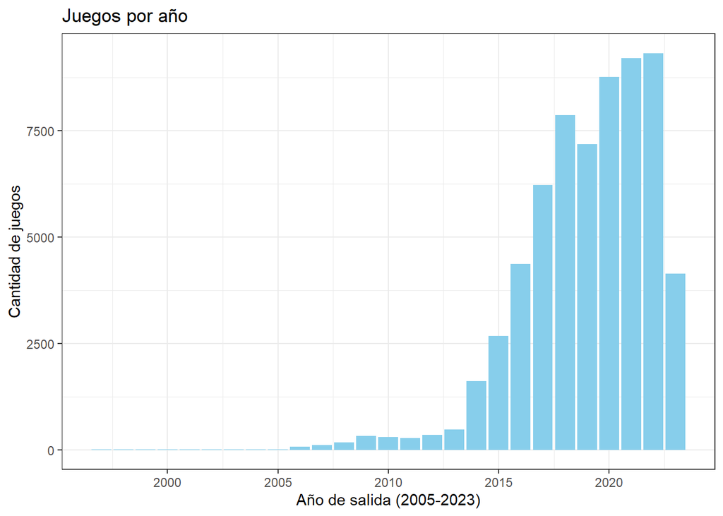

```r
datos |>
  # Inicia la visualización
  ggplot(aes(x = year)) +
  # Añade un gráfico de barras, rellenando las barras
  geom_bar(fill = "skyblue") +
  theme_bw() +
  # Establece los títulos del gráfico, eje x, y eje y.
  labs(title = "Juegos por año",
       x = "Año de salida (2005-2023)",
       y = "Cantidad de juegos")
```

```r
datos |> descr(year)
```

```
## Descriptive Statistics
## datos$year
## N: 63543
##
##                         year
## ----------------- ----------
##              Mean    2019.03
##           Std.Dev       2.85
##               Min    1997.00
##                Q1    2017.00
##            Median    2019.00
##                Q3    2021.00
##               Max    2023.00
##               MAD       2.97
##               IQR       4.00
##                CV       0.00
##          Skewness      -1.09
##       SE.Skewness       0.01
##          Kurtosis       2.13
##           N.Valid   63443.00
##         Pct.Valid      99.84
```

Podemos observar como la producción de los videojuegos lleva en auge las últimas décadas, haciendo un salto en 2015, además de cómo se frenó la caida de la industria en el año 2020 debido a la pandemia mundial y a la cuarentena.

### Variable ‘metacritic_rating’

```r
#Crea una tabla de frecuencias
tabla_frecuencias2 <- as.data.frame(table(datos$metacritic_rating))

#Calcula la frecuencia relativa (f), frecuencia acumulada (N) y frecuencia relativa acumulada (F)
tabla_frecuencias2 <- tabla_frecuencias2 %>%
  mutate(f = Freq / sum(Freq),         # Frecuencia relativa
         N = cumsum(Freq),             # Frecuencia acumulada
         F = cumsum(f))                # Frecuencia relativa acumulada

#Muestra la tabla con formato
knitr::kable(tabla_frecuencias2, digits = 4)
```

| Var1 | Freq | f | N | F |
| --- | --- | --- | --- | --- |
| 20 | 1 | 0.0003 | 1 | 0.0003 |
| 23 | 1 | 0.0003 | 2 | 0.0005 |
| 24 | 1 | 0.0003 | 3 | 0.0008 |
| 27 | 2 | 0.0005 | 5 | 0.0013 |
| 29 | 2 | 0.0005 | 7 | 0.0018 |
| 30 | 2 | 0.0005 | 9 | 0.0023 |
| 32 | 2 | 0.0005 | 11 | 0.0028 |
| 33 | 1 | 0.0003 | 12 | 0.0031 |
| 34 | 3 | 0.0008 | 15 | 0.0038 |
| 35 | 3 | 0.0008 | 18 | 0.0046 |
| 36 | 2 | 0.0005 | 20 | 0.0051 |
| 37 | 3 | 0.0008 | 23 | 0.0059 |
| 38 | 4 | 0.0010 | 27 | 0.0069 |
| 39 | 5 | 0.0013 | 32 | 0.0082 |
| 40 | 5 | 0.0013 | 37 | 0.0094 |
| 41 | 9 | 0.0023 | 46 | 0.0117 |
| 42 | 3 | 0.0008 | 49 | 0.0125 |
| 43 | 13 | 0.0033 | 62 | 0.0158 |
| 44 | 7 | 0.0018 | 69 | 0.0176 |
| 45 | 6 | 0.0015 | 75 | 0.0192 |
| 46 | 9 | 0.0023 | 84 | 0.0215 |
| 47 | 10 | 0.0026 | 94 | 0.0240 |
| 48 | 14 | 0.0036 | 108 | 0.0276 |
| 49 | 17 | 0.0043 | 125 | 0.0319 |
| 50 | 13 | 0.0033 | 138 | 0.0352 |
| 51 | 20 | 0.0051 | 158 | 0.0403 |
| 52 | 17 | 0.0043 | 175 | 0.0447 |
| 53 | 29 | 0.0074 | 204 | 0.0521 |
| 54 | 33 | 0.0084 | 237 | 0.0605 |
| 55 | 32 | 0.0082 | 269 | 0.0687 |
| 56 | 30 | 0.0077 | 299 | 0.0764 |
| 57 | 39 | 0.0100 | 338 | 0.0863 |
| 58 | 45 | 0.0115 | 383 | 0.0978 |
| 59 | 49 | 0.0125 | 432 | 0.1103 |
| 60 | 38 | 0.0097 | 470 | 0.1200 |
| 61 | 59 | 0.0151 | 529 | 0.1351 |
| 62 | 61 | 0.0156 | 590 | 0.1507 |
| 63 | 73 | 0.0186 | 663 | 0.1693 |
| 64 | 63 | 0.0161 | 726 | 0.1854 |
| 65 | 91 | 0.0232 | 817 | 0.2086 |
| 66 | 98 | 0.0250 | 915 | 0.2337 |
| 67 | 85 | 0.0217 | 1000 | 0.2554 |
| 68 | 141 | 0.0360 | 1141 | 0.2914 |
| 69 | 126 | 0.0322 | 1267 | 0.3235 |
| 70 | 134 | 0.0342 | 1401 | 0.3578 |
| 71 | 116 | 0.0296 | 1517 | 0.3874 |
| 72 | 143 | 0.0365 | 1660 | 0.4239 |
| 73 | 163 | 0.0416 | 1823 | 0.4655 |
| 74 | 146 | 0.0373 | 1969 | 0.5028 |
| 75 | 163 | 0.0416 | 2132 | 0.5444 |
| 76 | 174 | 0.0444 | 2306 | 0.5889 |
| 77 | 160 | 0.0409 | 2466 | 0.6297 |
| 78 | 172 | 0.0439 | 2638 | 0.6736 |
| 79 | 152 | 0.0388 | 2790 | 0.7125 |
| 80 | 194 | 0.0495 | 2984 | 0.7620 |
| 81 | 170 | 0.0434 | 3154 | 0.8054 |
| 82 | 131 | 0.0335 | 3285 | 0.8389 |
| 83 | 129 | 0.0329 | 3414 | 0.8718 |
| 84 | 103 | 0.0263 | 3517 | 0.8981 |
| 85 | 85 | 0.0217 | 3602 | 0.9198 |
| 86 | 73 | 0.0186 | 3675 | 0.9385 |
| 87 | 61 | 0.0156 | 3736 | 0.9540 |
| 88 | 37 | 0.0094 | 3773 | 0.9635 |
| 89 | 43 | 0.0110 | 3816 | 0.9745 |
| 90 | 28 | 0.0072 | 3844 | 0.9816 |
| 91 | 28 | 0.0072 | 3872 | 0.9888 |
| 92 | 11 | 0.0028 | 3883 | 0.9916 |
| 93 | 14 | 0.0036 | 3897 | 0.9951 |
| 94 | 12 | 0.0031 | 3909 | 0.9982 |
| 95 | 2 | 0.0005 | 3911 | 0.9987 |
| 96 | 4 | 0.0010 | 3915 | 0.9997 |
| 97 | 1 | 0.0003 | 3916 | 1.0000 |

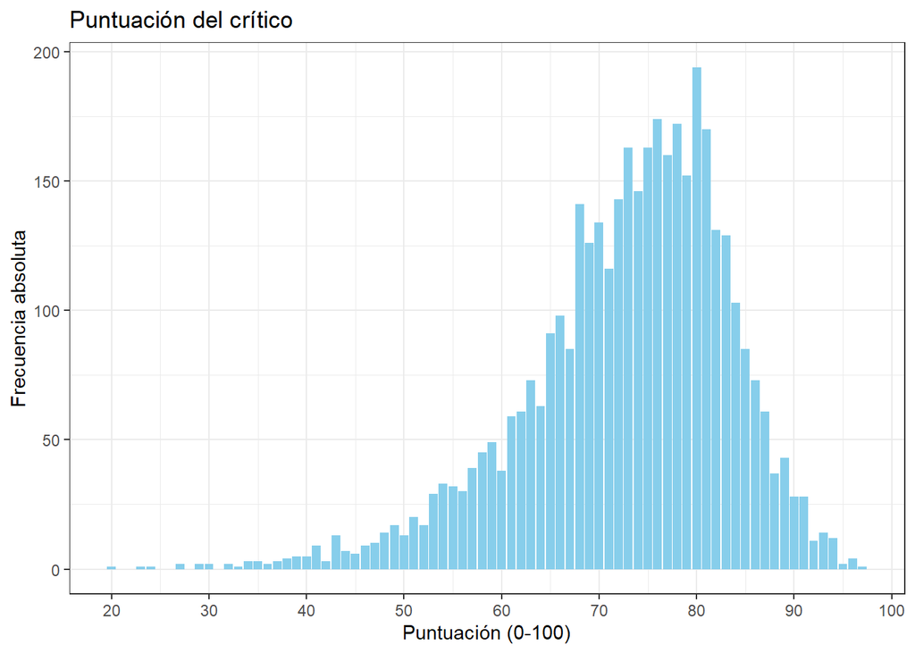

```r
datos |>
  # Inicia una visualización
  ggplot(aes(x = metacritic_rating)) +
  # Añade un gráfico de barras, rellenando las barras
  geom_bar(fill = "skyblue") +
  theme_bw() +
  # Establece los títulos del gráfico, eje x, y eje y.
  labs(title = "Puntuación del crítico",
       x = "Puntuación (0-100)",
       y = "Frecuencia absoluta") +
   scale_x_continuous(breaks = seq(20, 100, by = 10))  # Define más marcas en el eje X cada 10 unidades
```

En este gráfico se observa que las puntuaciones más frecuentes se encuentran entre los 60 y 85 puntos. La puntuación más frecuente, es decir, la moda, son 80 puntos, llegando a una frecuencia de casi 200.

```r
summary(datos$metacritic_rating)
```

```
##    Min. 1st Qu.  Median    Mean 3rd Qu.    Max.    NA's
##   20.00   67.00   74.00   72.84   80.00   97.00   59627
```

La información se amplía con este resumen en el que destacamos que la puntuación media son 72,84 puntos. La nota más baja son 20 puntos y la más alta 97 puntos. Se concluye que no hay ningún juego que tenga una puntuación de 100.

### Variable ‘reviewer_rating’

```r
# Crea una tabla de frecuencias
tabla_frecuencias2 <- as.data.frame(table(datos$reviewer_rating))

# Calcula la frecuencia relativa (f), frecuencia acumulada (N) y frecuencia relativa acumulada (F)
tabla_frecuencias2 <- tabla_frecuencias2 %>%
  mutate(f = Freq / sum(Freq),         # Frecuencia relativa
         N = cumsum(Freq),             # Frecuencia acumulada
         F = cumsum(f))                # Frecuencia relativa acumulada

#Muestra la tabla con formato
knitr::kable(tabla_frecuencias2, digits = 4)
```

| Var1 | Freq | f | N | F |
| --- | --- | --- | --- | --- |
| 1 | 11 | 0.0002 | 11 | 0.0002 |
| 2 | 64 | 0.0014 | 75 | 0.0017 |
| 3 | 322 | 0.0072 | 397 | 0.0089 |
| 4 | 2136 | 0.0479 | 2533 | 0.0568 |
| 5 | 11902 | 0.2667 | 14435 | 0.3234 |
| 6 | 8023 | 0.1798 | 22458 | 0.5032 |
| 7 | 9287 | 0.2081 | 31745 | 0.7113 |
| 8 | 11919 | 0.2671 | 43664 | 0.9784 |
| 9 | 965 | 0.0216 | 44629 | 1.0000 |

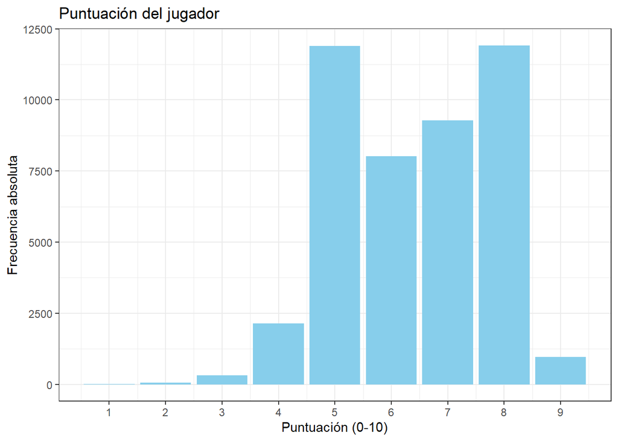

```r
datos |>
  # Inicia una visualización
  ggplot(aes(x = reviewer_rating)) +
  # Añade un gráfico de barras, rellenando las barras
   geom_bar(fill = "skyblue") +
  theme_bw() +
  # Establece los títulos del gráfico, eje x, y eje y.
  labs(title = "Puntuación del jugador",
       x = "Puntuación (0-10)",
       y = "Frecuencia absoluta") +
  scale_x_continuous(breaks = seq(0, 10, by = 1))  # Define más marcas en el eje X cada unidad
```

En este gráfico se observa que las puntuaciones más frecuentes se encuentran entre los 5 y 8 puntos. La puntuación más frecuente, es decir, la moda, son 8 puntos, seguido muy de cerca por los 5 puntos.

```r
summary(datos$reviewer_rating)
```

```
##    Min. 1st Qu.  Median    Mean 3rd Qu.    Max.    NA's
##   1.000   5.000   6.000   6.416   8.000   9.000   18914
```

### Variable ‘positivity_ratio’

```r
# Crear la tabla de frecuencias a partir de datos$positivity_ratio
tabla_frecuencias2 <- as.data.frame(table(datos$positivity_ratio))

# Calcular la frecuencia relativa (f), frecuencia acumulada (N) y frecuencia relativa acumulada (F)
tabla_frecuencias2 <- tabla_frecuencias2 %>%
  mutate(f = Freq / sum(Freq),  # Frecuencia relativa
         N = cumsum(Freq),      # Frecuencia acumulada
         F = cumsum(f))         # Frecuencia relativa acumulada

# Filtrar los 10 menos frecuentes y los 10 más frecuentes
tabla_top_bottom <- tabla_frecuencias2 %>%
  arrange(Freq) %>%                       # Ordenar por frecuencia
  slice(c(1:10, (n() - 9):n()))           # Seleccionar las 10 primeras y 10 últimas filas

# Mostrar la tabla formateada con knitr
knitr::kable(tabla_top_bottom, digits = 4,
             caption = "Tabla de Frecuencias: 10 Menos y Más Frecuentes")
```

Tabla de Frecuencias: 10 Menos y Más Frecuentes

| Var1 | Freq | f | N | F |
| --- | --- | --- | --- | --- |
| 0.02 | 1 | 0.0000 | 1 | 0.0000 |
| 0.037037037037037 | 1 | 0.0000 | 2 | 0.0000 |
| 0.038461538461538 | 1 | 0.0000 | 3 | 0.0000 |
| 0.043478260869565 | 1 | 0.0000 | 4 | 0.0001 |
| 0.045454545454545 | 1 | 0.0000 | 5 | 0.0001 |
| 0.074074074074074 | 1 | 0.0000 | 23 | 0.0004 |
| 0.082304526748971 | 1 | 0.0000 | 34 | 0.0006 |
| 0.095238095238095 | 1 | 0.0000 | 73 | 0.0012 |
| 0.096774193548387 | 1 | 0.0000 | 74 | 0.0012 |
| 0.10344827586207 | 1 | 0.0000 | 96 | 0.0016 |
| 7 | 678 | 0.0110 | 49258 | 0.8006 |
| 2.5 | 697 | 0.0113 | 28827 | 0.4685 |
| 6 | 848 | 0.0138 | 46821 | 0.7609 |
| 1.5 | 991 | 0.0161 | 18432 | 0.2996 |
| 5 | 1076 | 0.0175 | 43709 | 0.7104 |
| 0.5 | 1440 | 0.0234 | 4528 | 0.0736 |
| 4 | 1495 | 0.0243 | 39493 | 0.6418 |
| 3 | 2042 | 0.0332 | 33460 | 0.5438 |
| 2 | 2870 | 0.0466 | 25026 | 0.4067 |
| 1 | 4118 | 0.0669 | 13072 | 0.2124 |

### Variable ‘to_beat_main’

```r
# Crear una tabla de frecuencias a partir de la variable 'to_beat_main'
tabla_frecuencias2 <- as.data.frame(table(datos$to_beat_main))

# Calcular la frecuencia relativa (f), frecuencia acumulada (N) y frecuencia relativa acumulada (F)

tabla_frecuencias2 <- tabla_frecuencias2 %>%
  mutate(f = Freq / sum(Freq),         # Frecuencia relativa
         N = cumsum(Freq),             # Frecuencia acumulada
         F = cumsum(f))                # Frecuencia relativa acumulada

# Filtrar solo los primeros 25 valores de la tabla
tabla_frecuencias2_top25 <- tabla_frecuencias2 %>%
  slice(1:25)  # Seleccionar las primeras 25 filas

# Mostrar la tabla con formato usando knitr::kable
knitr::kable(tabla_frecuencias2_top25, digits = 4,
             caption = "Primeros 25 Valores de 'to_beat_main'")
```

Primeros 25 Valores de ‘to_beat_main’

| Var1 | Freq | f | N | F |
| --- | --- | --- | --- | --- |
| 0.01 | 1 | 0.0001 | 1 | 0.0001 |
| 0.02 | 15 | 0.0008 | 16 | 0.0009 |
| 0.03 | 14 | 0.0008 | 30 | 0.0017 |
| 0.04 | 7 | 0.0004 | 37 | 0.0021 |
| 0.05 | 28 | 0.0016 | 65 | 0.0037 |
| 0.06 | 13 | 0.0007 | 78 | 0.0044 |
| 0.07 | 26 | 0.0015 | 104 | 0.0058 |
| 0.08 | 38 | 0.0021 | 142 | 0.0080 |
| 0.09 | 13 | 0.0007 | 155 | 0.0087 |
| 0.1 | 27 | 0.0015 | 182 | 0.0102 |
| 0.11 | 9 | 0.0005 | 191 | 0.0107 |
| 0.12 | 13 | 0.0007 | 204 | 0.0115 |
| 0.13 | 23 | 0.0013 | 227 | 0.0128 |
| 0.14 | 9 | 0.0005 | 236 | 0.0133 |
| 0.15 | 26 | 0.0015 | 262 | 0.0147 |
| 0.16 | 21 | 0.0012 | 283 | 0.0159 |
| 0.17 | 67 | 0.0038 | 350 | 0.0197 |
| 0.18 | 22 | 0.0012 | 372 | 0.0209 |
| 0.19 | 20 | 0.0011 | 392 | 0.0220 |
| 0.2 | 25 | 0.0014 | 417 | 0.0234 |
| 0.21 | 18 | 0.0010 | 435 | 0.0244 |
| 0.22 | 24 | 0.0013 | 459 | 0.0258 |
| 0.23 | 31 | 0.0017 | 490 | 0.0275 |
| 0.24 | 20 | 0.0011 | 510 | 0.0287 |
| 0.25 | 66 | 0.0037 | 576 | 0.0324 |

### Variable ‘to_beat_extra’

```r
# Crea una tabla de frecuencias a partir de la variable 'to_beat_extra'
tabla_frecuencias2 <- as.data.frame(table(datos$to_beat_extra))

# Calcula la frecuencia relativa (f), frecuencia acumulada (N) y frecuencia relativa acumulada (F)

tabla_frecuencias2 <- tabla_frecuencias2 %>%
  mutate(f = Freq / sum(Freq),         # Frecuencia relativa
         N = cumsum(Freq),             # Frecuencia acumulada
         F = cumsum(f))                # Frecuencia relativa acumulada

# Filtrar los primeros 25 valores del dataset
tabla_frecuencias2_top25 <- tabla_frecuencias2 %>%
  slice(1:25)  # Seleccionar las primeras 25 filas

# Mostrar la tabla con formato usando knitr::kable
knitr::kable(tabla_frecuencias2_top25, digits = 4,
             caption = "Primeros 25 Valores de 'to_beat_extra'")
```

Primeros 25 Valores de ‘to_beat_extra’

| Var1 | Freq | f | N | F |
| --- | --- | --- | --- | --- |
| 0.03 | 1 | 0.0001 | 1 | 0.0001 |
| 0.06 | 1 | 0.0001 | 2 | 0.0001 |
| 0.07 | 4 | 0.0003 | 6 | 0.0004 |
| 0.08 | 11 | 0.0008 | 17 | 0.0013 |
| 0.09 | 2 | 0.0001 | 19 | 0.0014 |
| 0.1 | 9 | 0.0007 | 28 | 0.0021 |
| 0.11 | 3 | 0.0002 | 31 | 0.0023 |
| 0.12 | 2 | 0.0001 | 33 | 0.0025 |
| 0.13 | 4 | 0.0003 | 37 | 0.0028 |
| 0.14 | 5 | 0.0004 | 42 | 0.0031 |
| 0.15 | 5 | 0.0004 | 47 | 0.0035 |
| 0.16 | 3 | 0.0002 | 50 | 0.0037 |
| 0.17 | 10 | 0.0007 | 60 | 0.0045 |
| 0.18 | 9 | 0.0007 | 69 | 0.0051 |
| 0.19 | 8 | 0.0006 | 77 | 0.0057 |
| 0.2 | 11 | 0.0008 | 88 | 0.0066 |
| 0.21 | 5 | 0.0004 | 93 | 0.0069 |
| 0.22 | 8 | 0.0006 | 101 | 0.0075 |
| 0.23 | 6 | 0.0004 | 107 | 0.0080 |
| 0.24 | 11 | 0.0008 | 118 | 0.0088 |
| 0.25 | 21 | 0.0016 | 139 | 0.0104 |
| 0.26 | 6 | 0.0004 | 145 | 0.0108 |
| 0.27 | 3 | 0.0002 | 148 | 0.0110 |
| 0.28 | 10 | 0.0007 | 158 | 0.0118 |
| 0.29 | 3 | 0.0002 | 161 | 0.0120 |

### Variable ‘to_beat_completionist’

```r
# Crea una tabla de frecuencias
tabla_frecuencias2 <- as.data.frame(table(datos$to_beat_completionist))

# Calcula la frecuencia relativa (f), frecuencia acumulada (N) y frecuencia relativa acumulada (F)
tabla_frecuencias2 <- tabla_frecuencias2 %>%
  mutate(f = Freq / sum(Freq),         # Frecuencia relativa
         N = cumsum(Freq),             # Frecuencia acumulada
         F = cumsum(f))                # Frecuencia relativa acumulada

# Filtrar los primeros 25 valores del dataset
tabla_frecuencias2_top25 <- tabla_frecuencias2 %>%
  slice(1:25)  # Seleccionar las primeras 25 filas

# Mostrar la tabla con formato usando knitr::kable
knitr::kable(tabla_frecuencias2_top25, digits = 4,
             caption = "Primeros 25 Valores de 'to_beat_completionist'")
```

Primeros 25 Valores de ‘to_beat_completionist’

| Var1 | Freq | f | N | F |
| --- | --- | --- | --- | --- |
| 0.02 | 47 | 0.0029 | 47 | 0.0029 |
| 0.03 | 22 | 0.0014 | 69 | 0.0043 |
| 0.04 | 6 | 0.0004 | 75 | 0.0047 |
| 0.05 | 20 | 0.0012 | 95 | 0.0059 |
| 0.06 | 4 | 0.0002 | 99 | 0.0062 |
| 0.07 | 17 | 0.0011 | 116 | 0.0072 |
| 0.08 | 18 | 0.0011 | 134 | 0.0084 |
| 0.09 | 12 | 0.0007 | 146 | 0.0091 |
| 0.1 | 16 | 0.0010 | 162 | 0.0101 |
| 0.11 | 12 | 0.0007 | 174 | 0.0109 |
| 0.12 | 23 | 0.0014 | 197 | 0.0123 |
| 0.13 | 15 | 0.0009 | 212 | 0.0132 |
| 0.14 | 8 | 0.0005 | 220 | 0.0137 |
| 0.15 | 14 | 0.0009 | 234 | 0.0146 |
| 0.16 | 6 | 0.0004 | 240 | 0.0150 |
| 0.17 | 29 | 0.0018 | 269 | 0.0168 |
| 0.18 | 27 | 0.0017 | 296 | 0.0185 |
| 0.19 | 2 | 0.0001 | 298 | 0.0186 |
| 0.2 | 15 | 0.0009 | 313 | 0.0195 |
| 0.21 | 10 | 0.0006 | 323 | 0.0201 |
| 0.22 | 21 | 0.0013 | 344 | 0.0215 |
| 0.23 | 30 | 0.0019 | 374 | 0.0233 |
| 0.24 | 16 | 0.0010 | 390 | 0.0243 |
| 0.25 | 43 | 0.0027 | 433 | 0.0270 |
| 0.26 | 12 | 0.0007 | 445 | 0.0278 |

### Variable ‘extra_content_length’

Esta variable no se va analizar debido a su poca relación con el resto del EDA.

### Variable ‘tags’

```r
# Paso 1: Separar las etiquetas usando strsplit con el delimitador |
tags_separados <- strsplit(datos$tags, "\\|")

# Paso 2: Aplanar la lista resultante en un vector
tags_vector <- unlist(tags_separados)

# Paso 3: Crear una tabla de frecuencias
tabla_frecuencias <- as.data.frame(table(tags_vector))

# Paso 4: Calcular la frecuencia relativa (f), frecuencia acumulada (N) y frecuencia relativa acumulada (F)
tabla_frecuencias <- tabla_frecuencias %>%
  mutate(f = Freq / sum(Freq),         # Frecuencia relativa
         N = cumsum(Freq),             # Frecuencia acumulada
         F = cumsum(f))                # Frecuencia relativa acumulada

# Paso 5: Filtrar los primeros 25 valores del dataset
tabla_frecuencias_top25 <- tabla_frecuencias %>%
  slice(1:25)  # Seleccionar las primeras 25 filas

# Mostrar la tabla con formato usando knitr::kable
knitr::kable(tabla_frecuencias_top25, digits = 4,
             caption = "Primeros 25 tags")
```

Primeros 25 tags

| tags_vector | Freq | f | N | F |
| --- | --- | --- | --- | --- |
| 1980s | 1520 | 0.0018 | 1520 | 0.0018 |
| 1990’s | 52 | 0.0001 | 1572 | 0.0019 |
| 2.5D | 1491 | 0.0018 | 3063 | 0.0037 |
| 2D | 18091 | 0.0217 | 21154 | 0.0254 |
| 2D Fighter | 874 | 0.0010 | 22028 | 0.0264 |
| 2D Platformer | 4128 | 0.0049 | 26156 | 0.0313 |
| 360 Video | 89 | 0.0001 | 26245 | 0.0315 |
| 3D | 9991 | 0.0120 | 36236 | 0.0434 |
| 3D Fighter | 579 | 0.0007 | 36815 | 0.0441 |
| 3D Platformer | 2379 | 0.0029 | 39194 | 0.0470 |
| 3D Vision | 539 | 0.0006 | 39733 | 0.0476 |
| 4 Player Local | 1238 | 0.0015 | 40971 | 0.0491 |
| 4X | 346 | 0.0004 | 41317 | 0.0495 |
| 6DOF | 539 | 0.0006 | 41856 | 0.0502 |
| 8-bit Music | 33 | 0.0000 | 41889 | 0.0502 |
| Abstract | 1512 | 0.0018 | 43401 | 0.0520 |
| Action | 29276 | 0.0351 | 72677 | 0.0871 |
| Action-Adventure | 5749 | 0.0069 | 78426 | 0.0940 |
| Action Roguelike | 1822 | 0.0022 | 80248 | 0.0962 |
| Action RPG | 2740 | 0.0033 | 82988 | 0.0995 |
| Action RTS | 233 | 0.0003 | 83221 | 0.0997 |
| Addictive | 574 | 0.0007 | 83795 | 0.1004 |
| Adventure | 27747 | 0.0333 | 111542 | 0.1337 |
| Agriculture | 446 | 0.0005 | 111988 | 0.1342 |
| Aliens | 1364 | 0.0016 | 113352 | 0.1358 |

A continuación, se realizará una gráfica que analizará las frecuencias de todos los ‘tags’ presentes en el dataset.

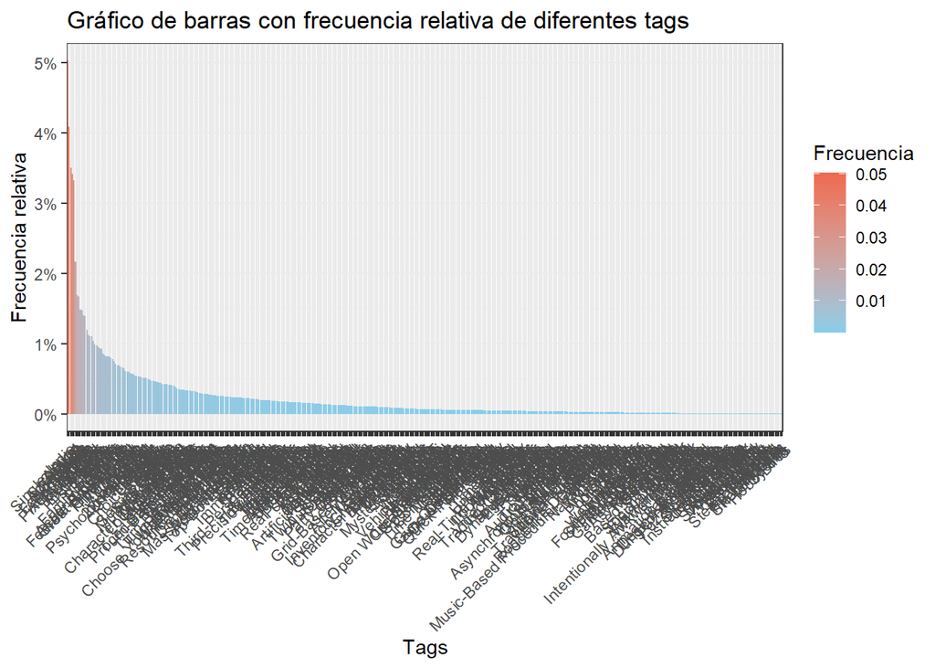

```r
tags_df <- data.frame(tags = unlist(tags_separados))
tags_df |> group_by(tags) |>  summarise(Frequency = n()) |> mutate(Frequency = Frequency/sum(Frequency), tags = reorder(tags, -Frequency)) |> ggplot(aes(x = tags, y = Frequency)) + geom_bar(stat = "identity", aes(fill = Frequency)) + scale_y_continuous(labels = scales::percent) + theme_bw() + labs(title = "Gráfico de barras con frecuencia relativa de diferentes tags", x = "Tags", y = "Frecuencia relativa") + scale_fill_gradient("Frecuencia", low = "skyblue", high = "coral2") + theme(axis.text.x = element_text(angle = 45, hjust = 1))
```

Como se puede comprobar, la cantidad de ‘tags’ es tal que la gráfica no es capaz de mostrarlas con claridad. Debido a esto, se llevarán a cabo dos gráficas más, una comprobará la frecuencia de los 25 ‘tags’ que lideran la gráfica anterior y, la otra, la frecuencia de los menos utilizadas.

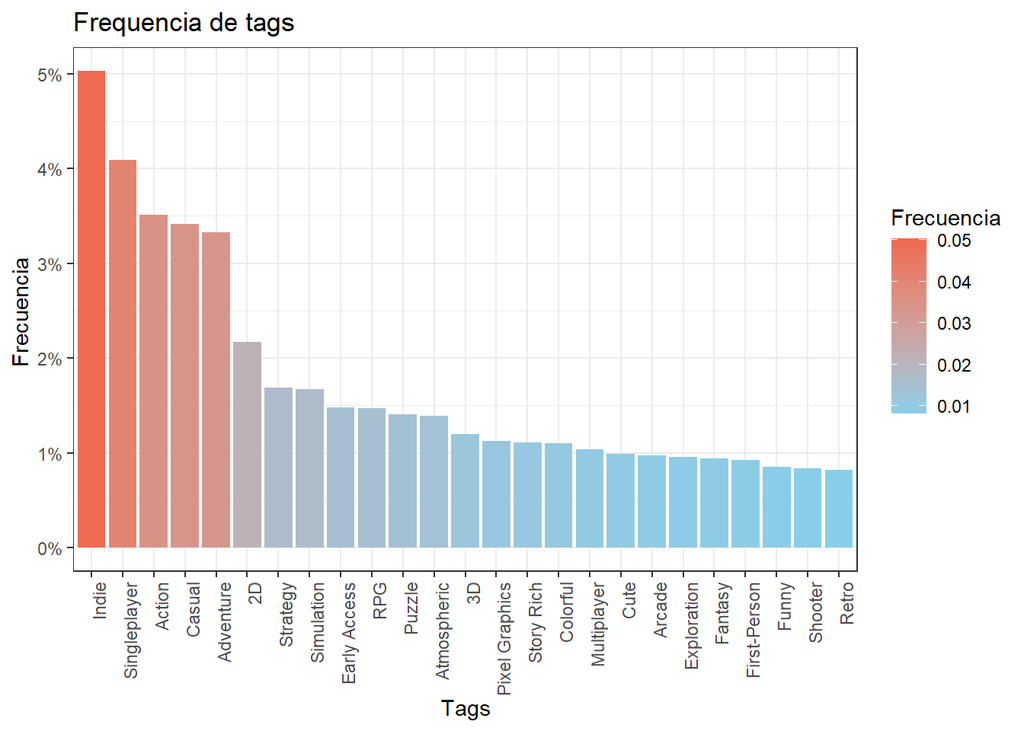

```r
tags_df <- data.frame(tags = unlist(tags_separados))

tags_freq <-tags_df %>%
  group_by(tags) %>%
  summarise(Frequency = n()) %>%
  mutate(Frequency = Frequency/ sum(Frequency)) %>%
  slice_max(Frequency, n=25) %>%
  mutate(tags = reorder(tags, -Frequency))

 ggplot(tags_freq, aes(x = tags, y = Frequency)) +
  # Añade un gráfico de barras
   geom_bar(stat = "identity", aes(fill = Frequency)) +
   scale_y_continuous(labels = scales::percent) +
  # Aplica un tema predeterminado en blanco y negro para la visualización.
  theme_bw() +
  # Establece los títulos del gráfico, eje x, y eje y.
  labs(title = "Frequencia de tags",
       x = "Tags",
       y = "Frecuencia ") +
   scale_fill_gradient("Frecuencia", low = "skyblue", high = "coral2") +
   theme(axis.text.x = element_text(angle = 90, hjust = 1))
```

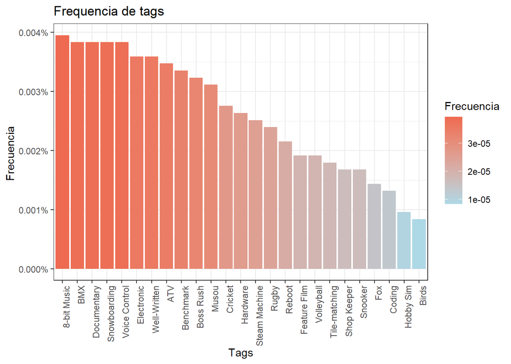

```r
tags_df <- data.frame(tags = unlist(tags_separados))

tags_freq <-tags_df %>%
  group_by(tags) %>%
  summarise(Frequency = n()) %>%
  mutate(Frequency = Frequency/ sum(Frequency)) %>%
  slice_min(Frequency, n=25) %>%
  mutate(tags = reorder(tags, -Frequency))

 ggplot(tags_freq, aes(x = tags, y = Frequency)) +
  # Añade un gráfico de barras
   geom_bar(stat = "identity", aes(fill = Frequency)) +
   scale_y_continuous(labels = scales::percent) +
  # Aplica un tema predeterminado en blanco y negro para la visualización.
  theme_bw() +
  # Establece los títulos del gráfico, eje x, y eje y.
  labs(title = "Frequencia de tags",
       x = "Tags",
       y = "Frecuencia ") +
   scale_fill_gradient("Frecuencia", low = "lightblue", high = "coral2") +
   theme(axis.text.x = element_text(angle = 90, hjust = 1))
```

## Datos bivariantes

Vamos a comprobar diversas variables para ver si tienen relación entre ellas, tanto en el impacto en sus opiniones como en el mercado.

Empezamos comparando los tags con el año de salida para encontrar los más frecuentes según a pasado el tiempo. Se continua analizando las distintas tags con el tiempo de duración de cada juego. Una vez acabado con los tags hablamos sobre como los años hab afectado a las críticas oficiales y si los jugadores están de acuerdo con estas puntaciones.

Por último buscamos relaciones entre las reviews de tanto críticos como jugadores con el tiempo de juego en busca de una posible relación entre la longitud de un juego y su recibimiento en la industria. Por último se realiza el mismo análisis con las tags en vez de la duración de los juegos.

### Análisis de ‘tags’ y ‘year’

A continuación, se comparará el año de salida de los juegos con el género de juego más producido cada año, seguido de un resumen en tabla de lo que dice el gráfico.

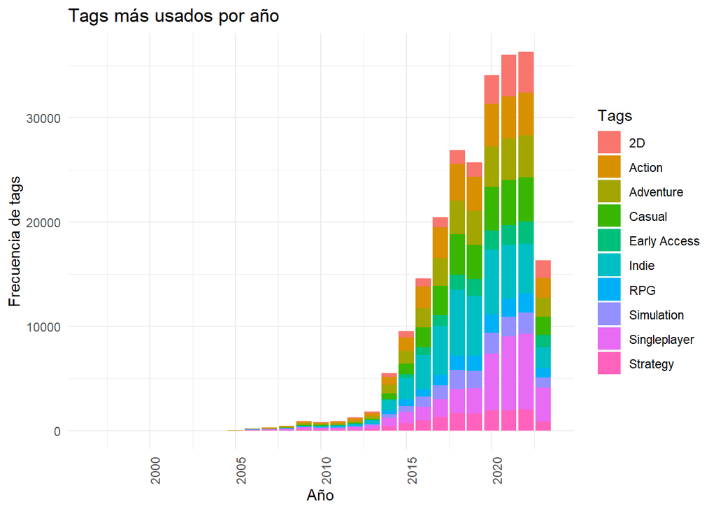

```r
# Paso 1: Separar los tags y mantener el año correspondiente
tags_separados <- datos %>%
  select(year, tags) %>%
  # Separar los tags en múltiples filas usando separate_rows
  separate_rows(tags, sep = "\\|")

# Paso 2: Contar las ocurrencias de cada tag por año
tags_por_año <- tags_separados %>%
  group_by(year, tags) %>%
  summarise(tag_count = n()) %>%
  ungroup()

# Paso 3: Filtrar los tags más frecuentes (opcional, por ejemplo, los 10 más frecuentes en total)
tags_mas_frecuentes <- tags_por_año %>%
  group_by(tags) %>%
  summarise(total_count = sum(tag_count)) %>%
  top_n(10, total_count)

# Paso 4: Filtrar los datos para mostrar solo los tags más frecuentes
tags_por_año_filtrado <- tags_por_año %>%
  filter(tags %in% tags_mas_frecuentes$tags)

# Paso 5: Graficar los tags más usados por año
ggplot(tags_por_año_filtrado, aes(x = year, y = tag_count, fill = tags)) +
  geom_bar(stat = "identity", position = "stack") +
  theme_minimal() +
  labs(title = "Tags más usados por año",
       x = "Año",
       y = "Frecuencia de tags",
       fill = "Tags") +
  theme(axis.text.x = element_text(angle = 90, hjust = 1))
```

```r
# Paso 1: Filtrar los datos de los últimos 10 años
ultimo_año <- max(datos$year, na.rm = TRUE)  # Obtener el año más reciente
datos_ultimos_10_años <- datos %>%
  filter(year >= (ultimo_año - 9))  # Filtrar los últimos 10 años

# Paso 2: Separar los tags para cada año dentro de los últimos 10 años
tags_separados_ultimos_10_años <- datos_ultimos_10_años %>%
  select(year, tags) %>%
  separate_rows(tags, sep = "\\|")  # Separar los tags en filas individuales

# Paso 3: Agrupar por año y por tag, y contar la frecuencia de los tags por año
conteo_tags_ultimos_10_años <- tags_separados_ultimos_10_años %>%
  group_by(year, tags) %>%
  summarise(frecuencia = n()) %>%
  arrange(year, desc(frecuencia))  # Ordenar por año y frecuencia descendente

# Paso 4: Seleccionar el tag más usado por cada año en los últimos 10 años
tags_mas_usados_ultimos_10_años <- conteo_tags_ultimos_10_años %>%
  group_by(year) %>%
  slice_max(frecuencia, n = 1)  # Obtener el tag más usado para cada año

# Mostrar los tags más usados por año en los últimos 10 años
print(tags_mas_usados_ultimos_10_años)
```

```
## # A tibble: 10 × 3
## # Groups:   year [10]
##     year tags         frecuencia
##    <dbl> <chr>             <int>
##  1  2014 Indie               995
##  2  2015 Indie              2049
##  3  2016 Indie              3256
##  4  2017 Indie              4662
##  5  2018 Indie              6325
##  6  2019 Indie              5710
##  7  2020 Indie              6246
##  8  2021 Singleplayer       7062
##  9  2022 Singleplayer       7269
## 10  2023 Singleplayer       3247
```

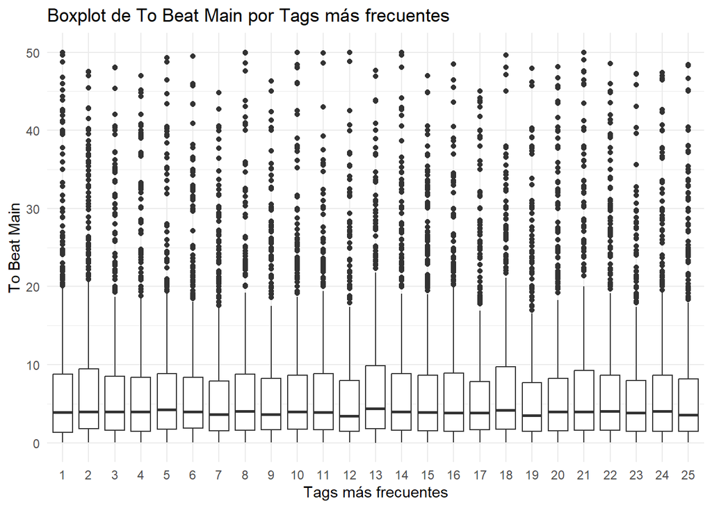

```r
datos$tags_freq <- sample(1:25, 63543, replace = TRUE)

# Filtrar valores por debajo de un umbral de 50 horas
datos_filtrados <- datos %>% filter(to_beat_main <= 50)

# Generar el boxplot con los datos filtrados
ggplot(datos_filtrados, aes(x = factor(tags_freq), y = to_beat_main)) +
  geom_boxplot() +
  labs(x = "Tags más frecuentes", y = "To Beat Main", title = "Boxplot de To Beat Main por Tags más frecuentes") +
  theme_minimal()
```

El gráfico muestra que la mayoría de los juegos tienen un tiempo de finalización relativamente corto, por debajo de 10 horas. Los puntos son los valores atípicos.

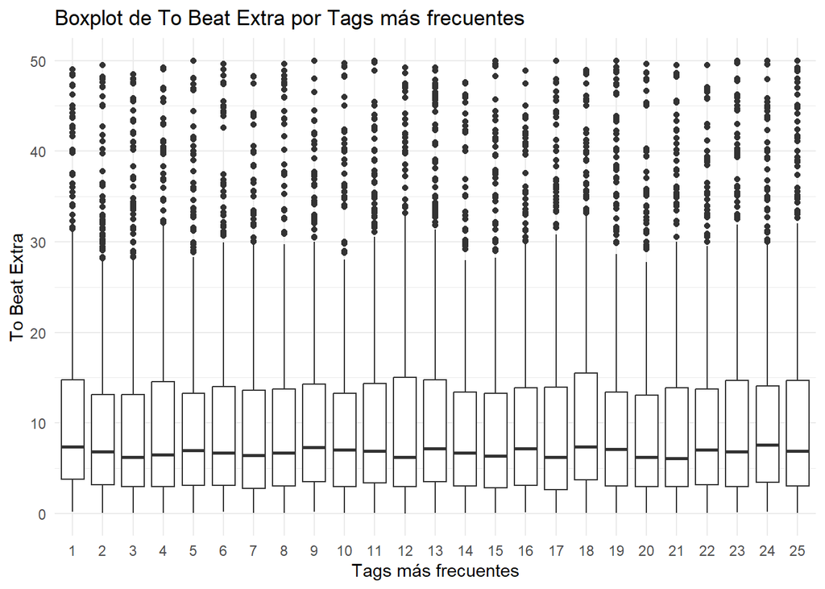

```r
datos$tags_freq <- sample(1:25, 63543, replace = TRUE)

# Filtrar valores por debajo de un umbral de 50 horas
datos_filtrados <- datos %>% filter(to_beat_extra <= 50)

# Generar el boxplot con los datos filtrados
ggplot(datos_filtrados, aes(x = factor(tags_freq), y = to_beat_extra)) +
  geom_boxplot() +
  labs(x = "Tags más frecuentes", y = "To Beat Extra", title = "Boxplot de To Beat Extra por Tags más frecuentes") +
  theme_minimal()
```

En este segundo gráfico se puede ver como los valores ascienden un poco estando entre las 15 y las 3 horas.

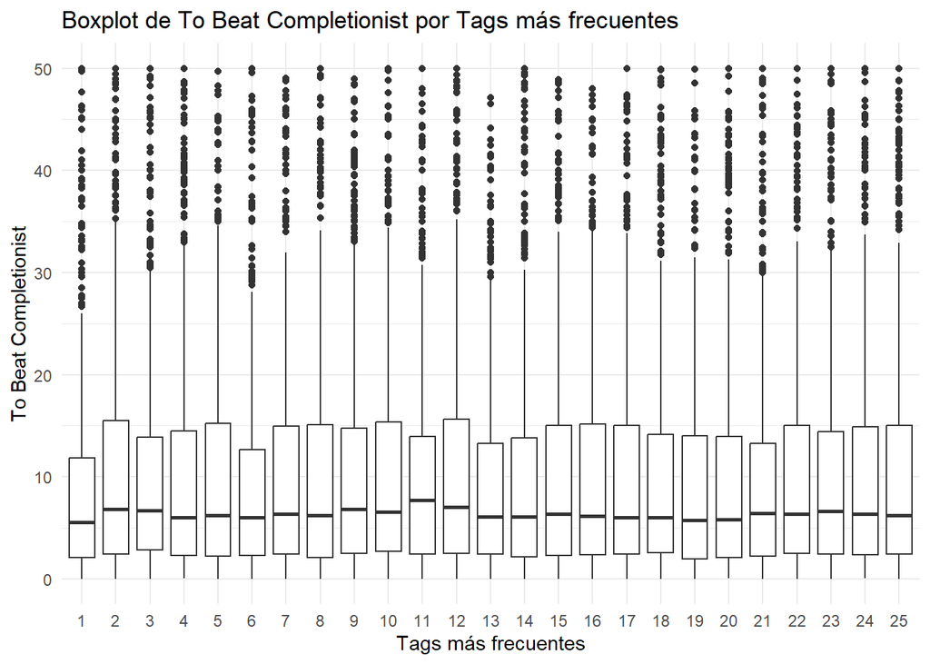

```r
datos$tags_freq <- sample(1:25, 63543, replace = TRUE)

# Filtrar valores por debajo de un umbral de 50 horas
datos_filtrados <- datos %>% filter(to_beat_completionist <= 50)

# Generar el boxplot con los datos filtrados
ggplot(datos_filtrados, aes(x = factor(tags_freq), y = to_beat_completionist)) +
  geom_boxplot() +
  labs(x = "Tags más frecuentes", y = "To Beat Completionist", title = "Boxplot de To Beat Completionist por Tags más frecuentes") +
  theme_minimal()
```

### Gráfico de densidad de to_beat_extra (Q narices es esto y q hace aquí???)

A continuación el gráfico de densidad de ‘to_beat_main’ sin agrupar datos:

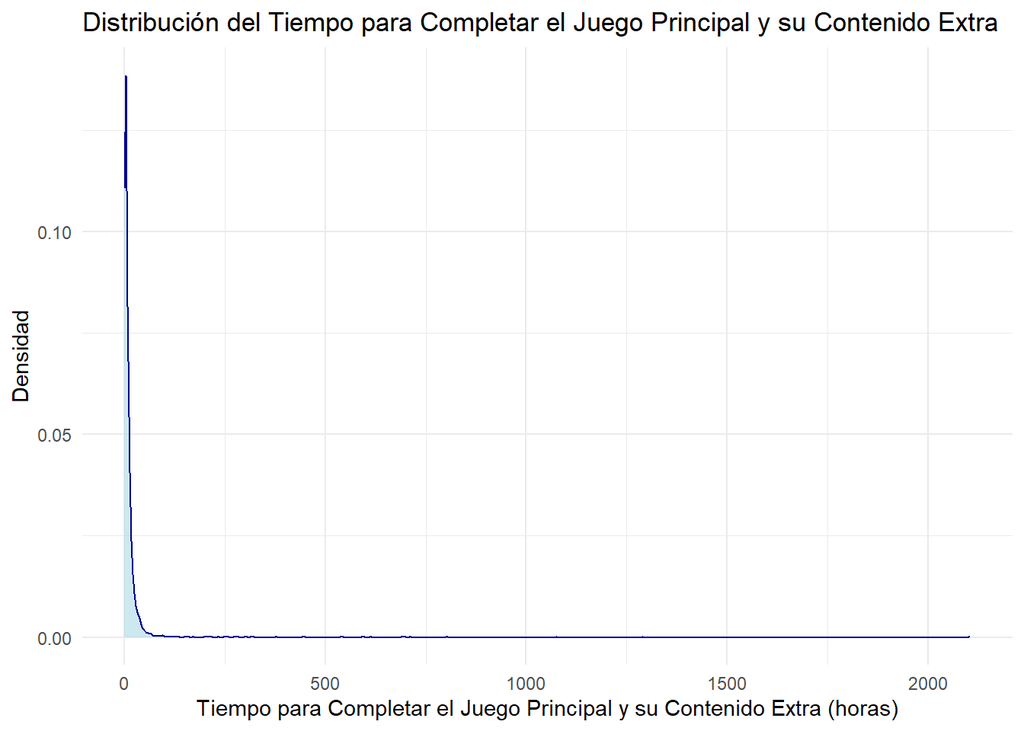

```r
# Filtrar los datos para eliminar valores NA
datos_filtrados <- datos %>%
  filter(!is.na(to_beat_extra))

# Crear el gráfico de densidad
ggplot(datos_filtrados, aes(x = to_beat_main)) +
  geom_density(fill = "lightblue", color = "darkblue", alpha = 0.6) +
  labs(title = "Distribución del Tiempo para Completar el Juego Principal y su Contenido Extra",
       x = "Tiempo para Completar el Juego Principal y su Contenido Extra (horas)",
       y = "Densidad") +
  theme_minimal()
```

Dado que la existencia de muy pocos datos con valores muy grandes dificulta el análisis del gráfico de densidad, se ha optado por hacer otro gráfico de densidad agrupando los datos más grandes, a partir de 50 horas, en un mismo valor. De este modo, es posible analizar con mayor precisión los datos en este rango de 0 a 50 horas, que es donde se encuentran la mayoría de ellos. Al aplicar este cambio, se obtiene el siguiente gráfico de densidad:

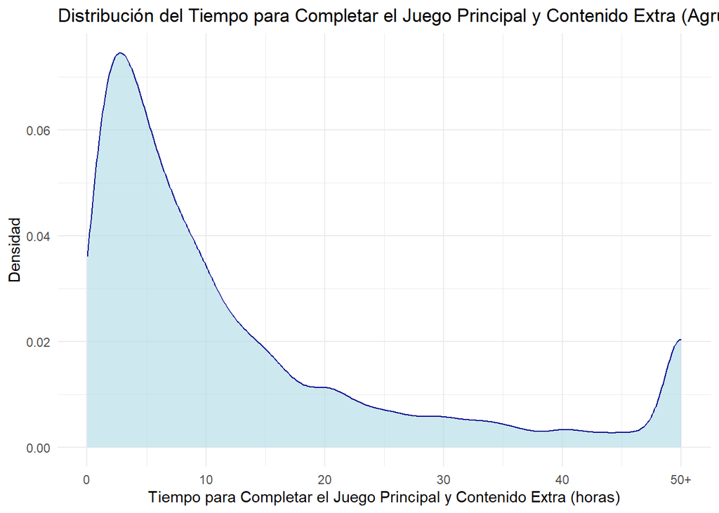

```r
# Filtrar los datos para eliminar valores NA
datos_filtrados_extra <- datos %>%
  filter(!is.na(to_beat_extra))

# Agrupar valores mayores a 50 horas en una nueva categoría
datos_filtrados_extra <- datos_filtrados_extra %>%
  mutate(to_beat_extra_grouped = ifelse(to_beat_extra > 50, 50, to_beat_extra))

# Crear el gráfico de densidad usando la variable agrupada
ggplot(datos_filtrados_extra, aes(x = to_beat_extra_grouped)) +
  geom_density(fill = "lightblue", color = "darkblue", alpha = 0.6) +
  labs(title = "Distribución del Tiempo para Completar el Juego Principal y Contenido Extra (Agrupando > 50h)",
       x = "Tiempo para Completar el Juego Principal y Contenido Extra (horas)",
       y = "Densidad") +
  theme_minimal() +
  scale_x_continuous(breaks = c(seq(0, 50, by = 10)), labels = c(seq(0, 40, by = 10), "50+"))
```

```r
# Resumen básico utilizando summary()
resumen_basico <- summary(datos$to_beat_extra)
print(resumen_basico)
```

```
##    Min. 1st Qu.  Median    Mean 3rd Qu.    Max.    NA's
##    0.03    3.31    7.50   20.00   16.50 6500.00   50116
```

```r
# Resumen más detallado utilizando psych
library(psych)
resumen_detallado <- describe(datos$to_beat_extra)
print(resumen_detallado)
```

```
##    vars     n mean     sd median trimmed  mad  min  max   range  skew kurtosis
## X1    1 13427   20 102.84    7.5    10.2 7.61 0.03 6500 6499.97 32.37  1516.95
##      se
## X1 0.89
```

```r
# Resumen utilizando dplyr para obtener media, mediana, desviación estándar, mínimo y máximo
resumen_tidy <- datos %>%
  summarise(
    media = mean(to_beat_extra, na.rm = TRUE),
    mediana = median(to_beat_extra, na.rm = TRUE),
    desviacion_estandar = sd(to_beat_extra, na.rm = TRUE),
    minimo = min(to_beat_extra, na.rm = TRUE),
    maximo = max(to_beat_extra, na.rm = TRUE)
  )

print(resumen_tidy)
```

```
## # A tibble: 1 × 5
##   media mediana desviacion_estandar minimo maximo
##   <dbl>   <dbl>               <dbl>  <dbl>  <dbl>
## 1  20.0     7.5                103.   0.03   6500
```

### Análisis de ‘year’ y ‘metacritic_rating’

Empezamos creando una tabla comparativa y calculando la covarianza y correlación:

```r
tabla_comparativa_años_criticas <- datos |>
  filter(!is.na(year), !is.na(metacritic_rating)) |>  # Excluir NA
  mutate(rango_años = cut(year, breaks = 7),
         rango_criticas = cut(metacritic_rating, breaks = 7)) |>
  count(rango_años, rango_criticas)

kable(tabla_comparativa_años_criticas)
```

| rango_años | rango_criticas | n |
| --- | --- | --- |
| (1997,2001] | (53,64] | 1 |
| (1997,2001] | (86,97.1] | 2 |
| (2001,2004] | (64,75] | 2 |
| (2001,2004] | (75,86] | 4 |
| (2001,2004] | (86,97.1] | 3 |
| (2004,2008] | (31,42] | 1 |
| (2004,2008] | (42,53] | 2 |
| (2004,2008] | (53,64] | 14 |
| (2004,2008] | (64,75] | 64 |
| (2004,2008] | (75,86] | 91 |
| (2004,2008] | (86,97.1] | 42 |
| (2008,2012] | (19.9,31] | 3 |
| (2008,2012] | (31,42] | 6 |
| (2008,2012] | (42,53] | 19 |
| (2008,2012] | (53,64] | 74 |
| (2008,2012] | (64,75] | 165 |
| (2008,2012] | (75,86] | 180 |
| (2008,2012] | (86,97.1] | 39 |
| (2012,2016] | (19.9,31] | 3 |
| (2012,2016] | (31,42] | 18 |
| (2012,2016] | (42,53] | 58 |
| (2012,2016] | (53,64] | 206 |
| (2012,2016] | (64,75] | 452 |
| (2012,2016] | (75,86] | 368 |
| (2012,2016] | (86,97.1] | 44 |
| (2016,2019] | (19.9,31] | 3 |
| (2016,2019] | (31,42] | 13 |
| (2016,2019] | (42,53] | 62 |
| (2016,2019] | (53,64] | 183 |
| (2016,2019] | (64,75] | 491 |
| (2016,2019] | (75,86] | 505 |
| (2016,2019] | (86,97.1] | 60 |
| (2019,2023] | (31,42] | 2 |
| (2019,2023] | (42,53] | 12 |
| (2019,2023] | (53,64] | 44 |
| (2019,2023] | (64,75] | 224 |
| (2019,2023] | (75,86] | 385 |
| (2019,2023] | (86,97.1] | 47 |

Covarianza:

```r
cov_año_criticos <- cov(datos$year, datos$metacritic_rating, use = "complete.obs")
cov_año_criticos
```

```
## [1] 1.87649
```

Correlación:

```r
cor_año_criticos <- cor(datos$year, datos$metacritic_rating, use = "complete.obs")
cor_año_criticos
```

```
## [1] 0.04348633
```

Gráfica de dispersión:

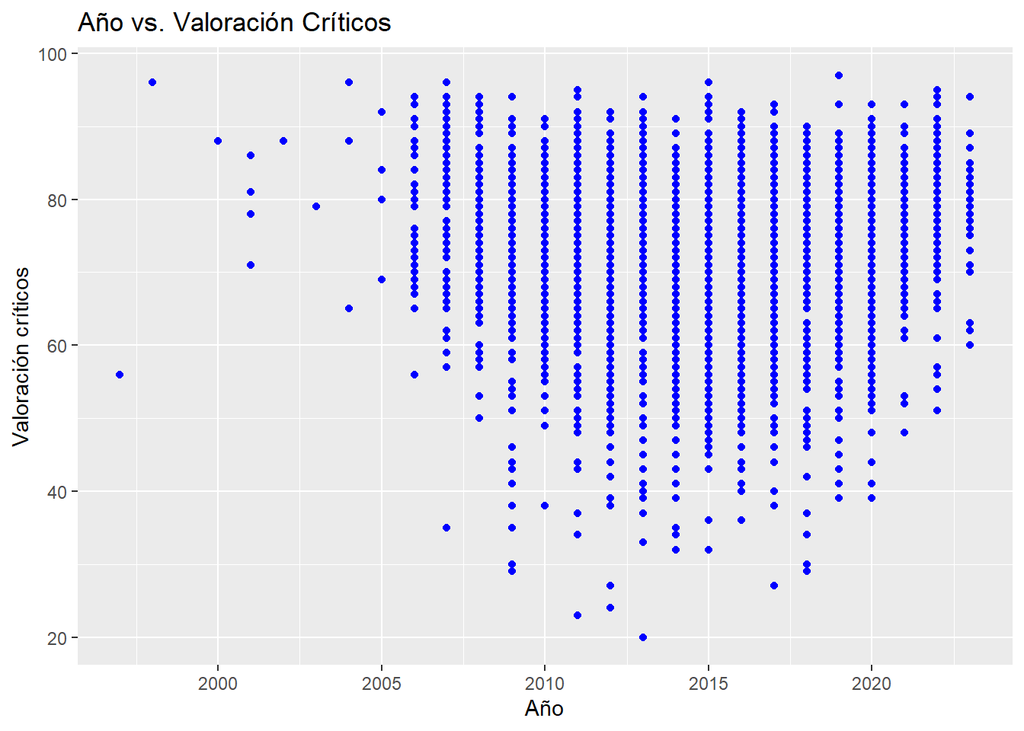

```r
ggplot(datos, aes(x = year, y = metacritic_rating, color = factor(tags_df))) +
  geom_point(color = "blue") +
  labs(x = "Año", y = "Valoración críticos") +
  ggtitle("Año vs. Valoración Críticos") +
  scale_color_discrete(name = "Tags")
```

Como es normal, podemos observar que hay mucha variedad en las valoraciónes de los críticos ya que cada juego es diferente, sin embargo podemos ver ciertas tendencias sobre los años y, según los expertos, que años tuvieron “mejores” salidas en la industria.

Tomamos en cuenta sobre todo los años de los que tenemos más datos y, tomando en cuenta que es una valoración sobre 100, desde el 2020 se percibe una supuesta mejora en las críticas, indicando que se han sacado al público mejores obras audiovisuales. Por el contrario desde el 2009 hasta 2013 hubo una peor calidad.

Regresión lineal:

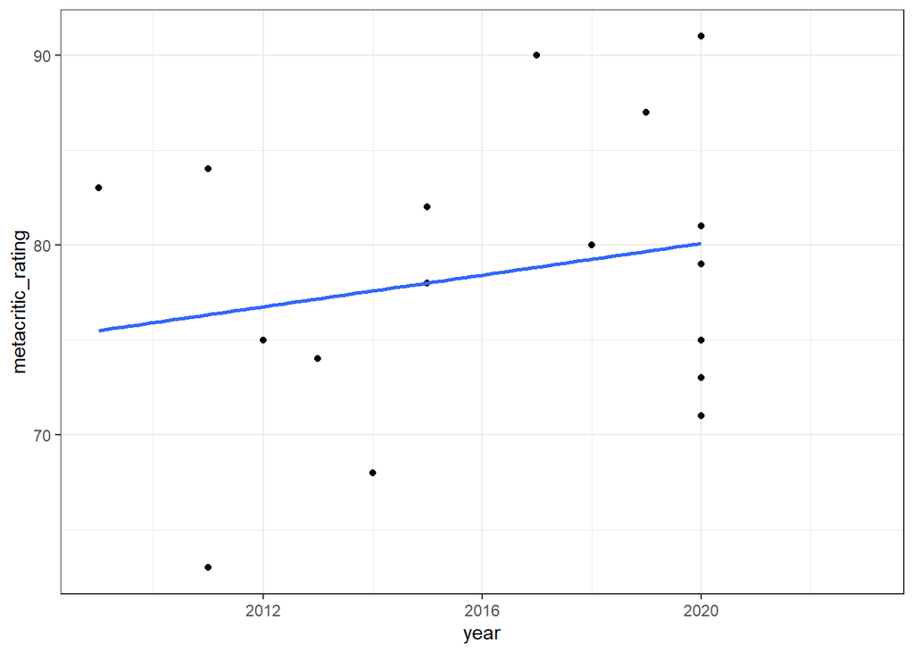

```r
datos |>
  slice(1:100) |>
  select(year, metacritic_rating) |>
  ggplot(aes(x=year, y = metacritic_rating)) +
  geom_point() +
  theme_bw() +
  geom_smooth(method = lm, se = FALSE)
```

Podemos determinar que la pendiente de la regresión lineal no es muy positiva, confirmando lo dicho con la correlación y covarianza.

```r
reg_año_critica <- lm(metacritic_rating ~ year, data = datos)
summary(reg_año_critica)
```

```
##
## Call:
## lm(formula = metacritic_rating ~ year, data = datos)
##
## Residuals:
##     Min      1Q  Median      3Q     Max
## -52.548  -5.548   1.554   7.340  25.136
##
## Coefficients:
##               Estimate Std. Error t value Pr(>|t|)
## (Intercept) -153.48449   83.36020  -1.841  0.06567 .
## year           0.11229    0.04136   2.715  0.00666 **
## ---
## Signif. codes:  0 '***' 0.001 '**' 0.01 '*' 0.05 '.' 0.1 ' ' 1
##
## Residual standard error: 10.55 on 3890 degrees of freedom
##   (59651 observations deleted due to missingness)
## Multiple R-squared:  0.001891,   Adjusted R-squared:  0.001634
## F-statistic:  7.37 on 1 and 3890 DF,  p-value: 0.006661
```

La regresión lineal sugiere que hay una relación positiva entre el año de lanzamiento del juego y su calificación por expertos, aunque la magnitud de esta relación es muy pequeña. Otros factores no considerados en esta sección del análisis podrían tener un mayor impacto en las calificaciones.

### Análisis de ‘metacritic_rating’ y ‘rewiewer_rating’

Se va a comparar las puntuaciones de los críticos oficiales con la puntuación dada por los jugadores (reviewers). Para ello se han seleccionado los 10 primeros juegos de la tabla, ignorando los juegos que no tenían valores de ‘metacritic_rating’ o ‘rewiewer_rating’.

Gráfico de barras ‘metacritic_rating’ y ‘rewiewer_rating’:

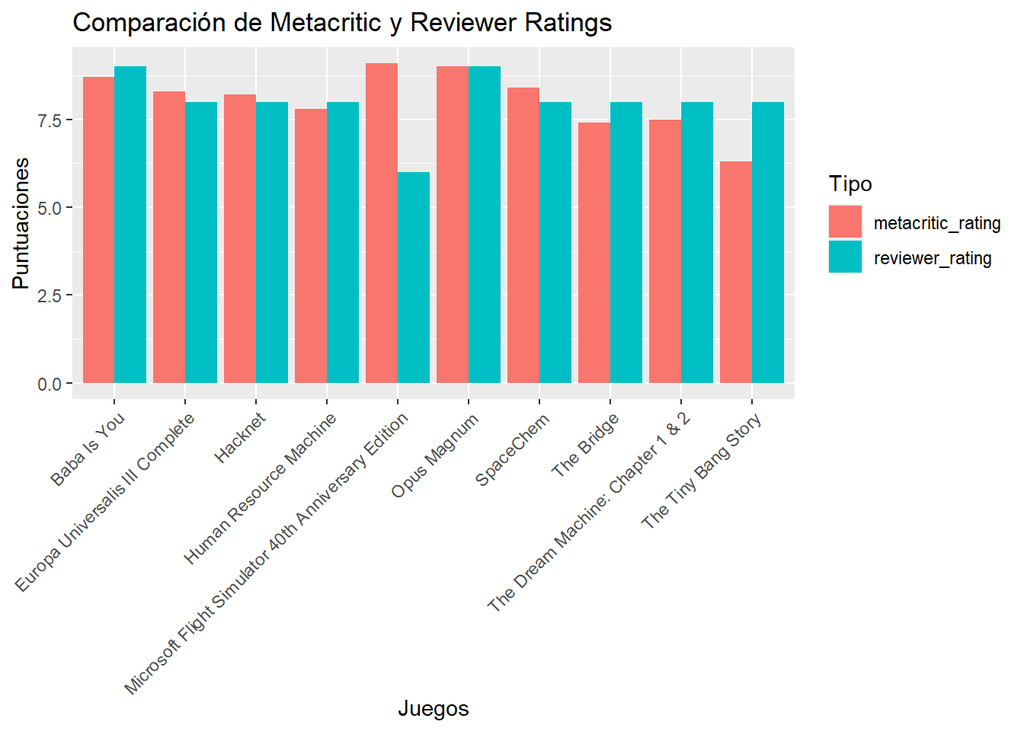

```r
# Transformar los datos al formato largo, seleccionar los 10 primeros y ajustar metacritic_rating
datos_long <- datos %>%
   # Filtrar filas donde metacritic_rating o reviewer_rating son NA
  filter(!is.na(metacritic_rating) & !is.na(reviewer_rating)) %>%
  slice_head(n = 10) %>%
  mutate(metacritic_rating = metacritic_rating / 10) %>%  # Ajustar la puntuación a sobre 10
  pivot_longer(cols = c(metacritic_rating, reviewer_rating),
               names_to = "tipo",
               values_to = "valor")

# Crear el gráfico de barras
ggplot(datos_long, aes(x = name, y = valor, fill = tipo)) +
  geom_bar(stat = "identity", position = position_dodge()) +
  labs(title = "Comparación de Metacritic y Reviewer Ratings",
       x = "Juegos",
       y = "Puntuaciones",
       fill = "Tipo") +
  theme(axis.text.x = element_text(angle = 45, hjust = 1))  # Rotar etiquetas
```

Con esto se puede observar que ambas puntuaciones suelen tener valores muy cercanos, incluso iguales, exceptuando algunos casos como por ejemplo “Microsoft Flight Simulator”, que ha sido mejor puntuado por los críticos, o “The Tiny Bang Story, que ha sido mejor puntuado por los jugadores.

También se ha realizado un gráfico de dispersión para visualizar mejor la correlación entre las dos puntuaciones.

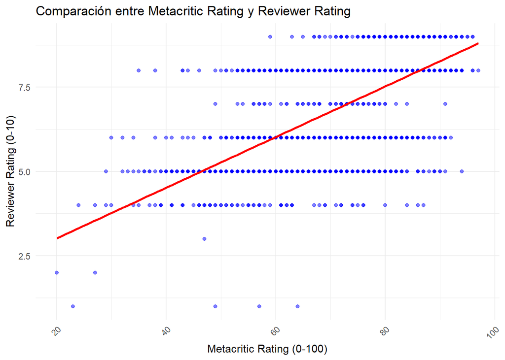

```r
ggplot(datos, aes(x = metacritic_rating, y = reviewer_rating)) +
  geom_point(alpha = 0.5, color = "blue") +  # Puntos de color azul con algo de transparencia
  geom_smooth(method = "lm", color = "red", se = FALSE) +  # Línea de tendencia lineal
  theme_minimal() +
  labs(title = "Comparación entre Metacritic Rating y Reviewer Rating",
       x = "Metacritic Rating (0-100)",
       y = "Reviewer Rating (0-10)") +
  theme(axis.text.x = element_text(angle = 45, hjust = 1))
```

### Análisis de ‘reviewer_rating’ y ‘metacritic_rating’ vs ‘to_beat_main’

Se han realizado dos gráficos de dispersión para ver si había algún tipo de correlación entre la puntuación de los críticos y los reviewers, y el tiempo para completar un juego.

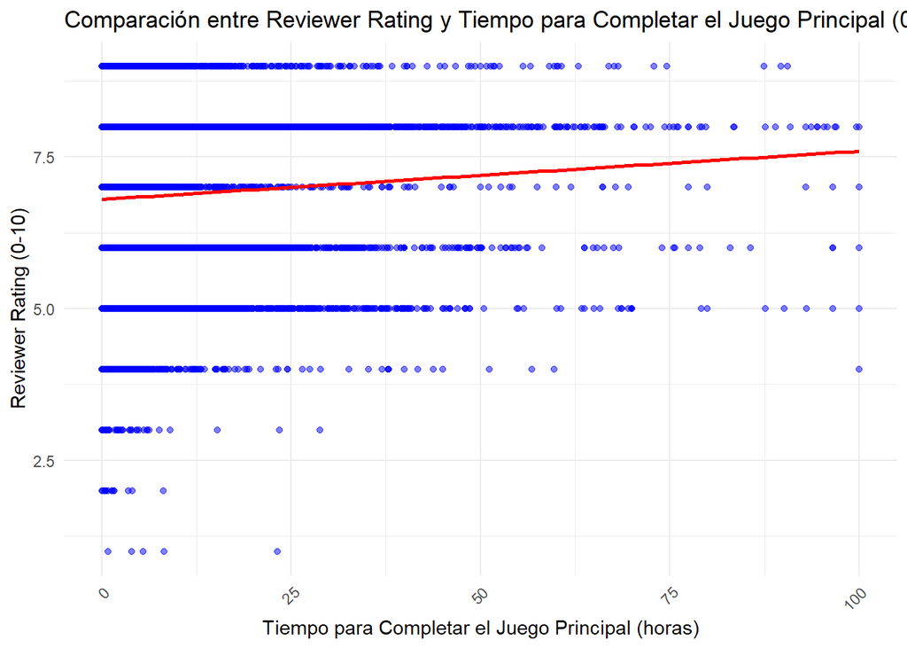

```r
# Filtrar los datos para mantener solo juegos con un tiempo de completar entre 0 y 100 horas
datos_filtrados <- datos %>%
  filter(to_beat_main >= 0 & to_beat_main <= 100)

# Gráfico de dispersión para comparar reviewer_rating y to_beat_main
ggplot(datos_filtrados, aes(x = to_beat_main, y = reviewer_rating)) +
  geom_point(alpha = 0.5, color = "blue") +  # Puntos de color azul con algo de transparencia
  geom_smooth(method = "lm", color = "red", se = FALSE) +  # Línea de tendencia lineal
  theme_minimal() +
  labs(title = "Comparación entre Reviewer Rating y Tiempo para Completar el Juego Principal (0-100h)",
       x = "Tiempo para Completar el Juego Principal (horas)",
       y = "Reviewer Rating (0-10)") +
  theme(axis.text.x = element_text(angle = 45, hjust = 1))
```

Correlación:

```r
cor_reviewer_main <- cor(datos$reviewer_rating, datos$to_beat_main, use = "complete.obs")
cor_reviewer_main
```

```
## [1] 0.01826266
```

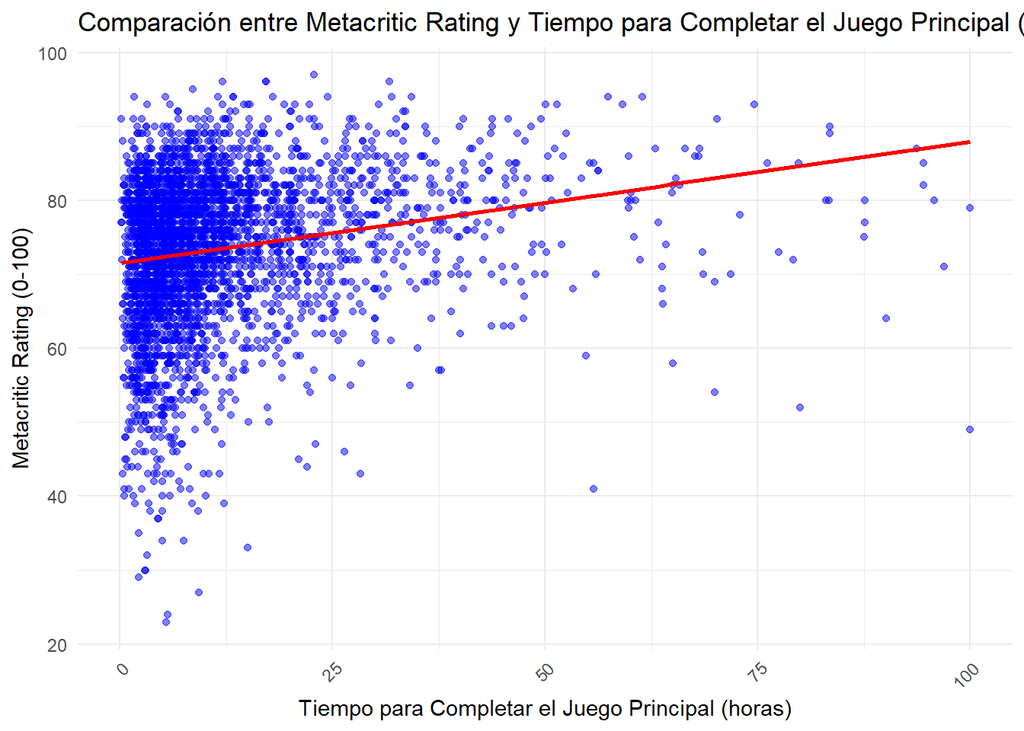

```r
# Filtrar los datos para mantener solo juegos con un tiempo de completar entre 0 y 100 horas
datos_filtrados <- datos %>%
  filter(to_beat_main >= 0 & to_beat_main <= 100)

# Gráfico de dispersión para comparar metacritic_rating y to_beat_main
ggplot(datos_filtrados, aes(x = to_beat_main, y = metacritic_rating)) +
  geom_point(alpha = 0.5, color = "blue") +  # Puntos de color azul con algo de transparencia
  geom_smooth(method = "lm", color = "red", se = FALSE) +  # Línea de tendencia lineal
  theme_minimal() +
  labs(title = "Comparación entre Metacritic Rating y Tiempo para Completar el Juego Principal (0-100h)",
       x = "Tiempo para Completar el Juego Principal (horas)",
       y = "Metacritic Rating (0-100)") +
  theme(axis.text.x = element_text(angle = 45, hjust = 1))
```

Correlación:

```r
cor_metacritic_main <- cor(datos$metacritic_rating, datos$to_beat_main, use = "complete.obs")
cor_metacritic_main
```

```
## [1] 0.1022525
```

Se puede observar en ambos casos que la correlación es muy baja tendiendo a cero por lo que no hay evidencia de que el tiempo en completar el juego principal tenga un impacto significativo en la puntuación de Metacritic o Reviewer Rating. Ambos gráficos tienen juegos con muy buenas puntuaciones que no tienen muchas horas de juego, lo mismo con muchas horas. No hay un patón distingible y se puede concluir que el tiempo no es una variable decisiva.

### Análisis de ‘to_beat_extra’ y ‘to_beat_completionist’ (Sustituir por lo de arriba)

A continuación se presenta un gráfico de dispersión entre las variables to_beat_extra y to_beat_completionist para estudiar la posible relación entre ambas:

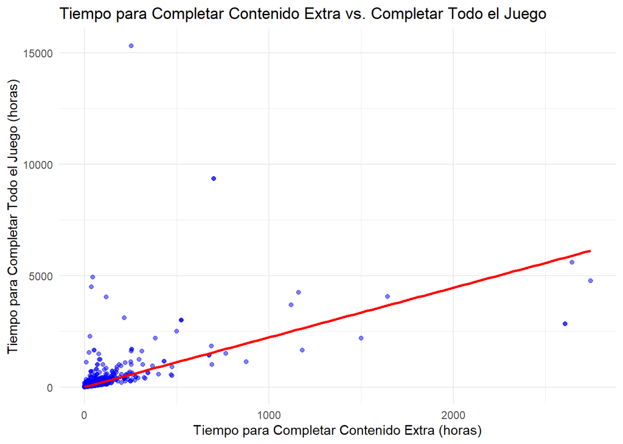

```r
# Filtrar los datos para eliminar valores NA en las variables to_beat_extra y to_beat_completionist
datos_filtrados_dispersion <- datos %>%
  filter(!is.na(to_beat_extra) & !is.na(to_beat_completionist))

# Crear el gráfico de dispersión
ggplot(datos_filtrados_dispersion, aes(x = to_beat_extra, y = to_beat_completionist)) +
  geom_point(color = "blue", alpha = 0.5) +  # Agregar puntos de dispersión
  labs(title = "Tiempo para Completar Contenido Extra vs. Completar Todo el Juego",
       x = "Tiempo para Completar Contenido Extra (horas)",
       y = "Tiempo para Completar Todo el Juego (horas)") +
  theme_minimal() +
  geom_smooth(method = "lm", se = FALSE, color = "red")  # Agregar una línea de regresión
```

De igual modo que se ha hecho con anterioridad, se procederá a agrupar los valores que más se alejan de donde se concentra la mayor parte de los datos, en este caso, para ello se mostrará un gráfico hasta 500 en el eje x y hasta 2000 en el eje y:

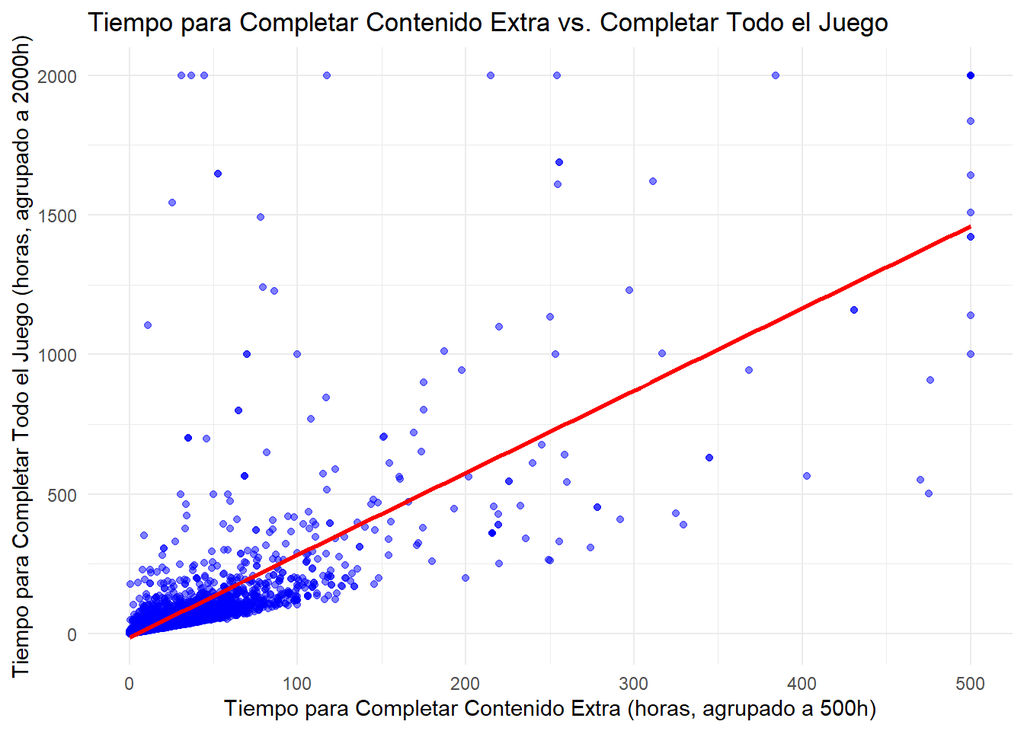

```r
# Filtrar los datos para eliminar valores NA en las variables to_beat_extra y to_beat_completionist
datos_filtrados_grouped <- datos %>%
  filter(!is.na(to_beat_extra) & !is.na(to_beat_completionist))

# Agrupar valores mayores a 500 horas en to_beat_extra y mayores a 2000 horas en to_beat_completionist
datos_filtrados_grouped <- datos_filtrados_grouped %>%
  mutate(to_beat_extra_grouped = ifelse(to_beat_extra > 500, 500, to_beat_extra),
         to_beat_completionist_grouped = ifelse(to_beat_completionist > 2000, 2000, to_beat_completionist))

# Crear el gráfico de dispersión agrupado
ggplot(datos_filtrados_grouped, aes(x = to_beat_extra_grouped, y = to_beat_completionist_grouped)) +
  geom_point(color = "blue", alpha = 0.5) +  # Agregar puntos de dispersión
  labs(title = "Tiempo para Completar Contenido Extra vs. Completar Todo el Juego",
       x = "Tiempo para Completar Contenido Extra (horas, agrupado a 500h)",
       y = "Tiempo para Completar Todo el Juego (horas, agrupado a 2000h)") +
  theme_minimal() +
  geom_smooth(method = "lm", se = FALSE, color = "red")  # Agregar una línea de regresión
```

Todos los valores que se salgan del rango marcado por los ejes en el gráfico, se colocarán en el límite de cada eje, es decir, 500 en el caso del eje de abscisas y 2000 en el eje de ordenadas.

Cálculo de correlación:

```r
# Filtrar datos para eliminar NA en to_beat_extra y to_beat_completionist
datos_filtrados_correlacion <- datos %>%
  filter(!is.na(to_beat_extra) & !is.na(to_beat_completionist))

# Calcular la correlación
correlation_value <- cor(datos_filtrados_correlacion$to_beat_extra,
                         datos_filtrados_correlacion$to_beat_completionist,
                         method = "pearson")

# Mostrar el resultado
correlation_value
```

```
## [1] 0.58101
```

Correlación de 0,58.

Tendencia lineal.

A partir de estos gráficos es posible establecer entonces una tendencia lineal entre ambas variables. No obstante, al contar con tan solo 0,58 de correlación, se podría aventurar que no son variables cuya relación lineal sea tan significativa. Ciertamente, es innegable que cuánto mayor sea el tiempo extra del juego, mayor será el tiempo total necesario para completar todos los objetivos, por lo tanto, no son variables completamente sin relación. Sin embargo, no es posible obviar que en su mayoría, los juegos suelen contar con muchas más horas de contenido principal que extra, por lo cual, ambas presentarían una correlación mayor.

# Conclusión

Empezamos comparando los tags con el año de salida para encontrar los más frecuentes según a pasado el tiempo. Se continua analizando las distintas tags con el tiempo de duración de cada juego. Una vez acabado con los tags hablamos sobre como los años hab afectado a las críticas oficiales y si los jugadores están de acuerdo con estas puntaciones.

Tras el completo análisis de los datos de estos últimos años en cuanto a juegos en la plataforma de Steam, se han encontrado diversos factores que verdaderamente afectan a la opinión del público o que categoría de juegos ha sido mayor tendencia en estas últimas décadas.